# Análise precisão

Gabriel Cintra

Francisco Edeverton

Maria Clara Dantas

Rafael Guerra

Raimundo Heitor

10 de julho de 2018

```r
library(tidyverse)
library(here)
library(modelr)
library(broom)
library(GGally)
theme_set(theme_bw())

set.seed(1456)
```

## Os dados

```r
reclamacoes = read_csv(here("data/3-avaliacao-humana/reclamacoes-avaliadas-20180703.csv"))
sentimentos = read_csv(here("data/5-sentimentos/sentimento.csv"))
reclamacoes = reclamacoes %>% mutate(comprimento_reclamacao = str_length(reclamacao))
```

`reclamacoes_l` tem um formato long em vez de wide (explicado [aqui](https://sejdemyr.github.io/r-tutorials/basics/wide-and-long/)).

```r
reclamacoes = reclamacoes %>%
    left_join(sentimentos, by = "id")

reclamacoes_l = reclamacoes %>%
    select(-palavras_op30, -palavras_sent, -grupo_avaliando) %>%
    gather(key = "lexico",
           value = "polaridade",
           sentimento_op30, sentimento_sent)

reclamacoes_l %>% View()
```

Definindo a função de cálculo de sentimento por palavra

```r
# Faça você mesmo. Crie a variável polaridade_normalizada
calcular_polaridade_normalizada <- function (polaridade) {
     BEST_SENTIMENT = max(polaridade)
     WORST_SENTIMENT = min(polaridade)
     LIKERT_RANGE = 5

     # F(num) = likert - int([num + |min|] / likert)
     normalize_function = LIKERT_RANGE - (as.integer((polaridade + abs(WORST_SENTIMENT)) / ((BEST_SENTIMENT + abs(WORST_SENTIMENT))/4)))

     return (normalize_function)
 }
```

Converte polaridades para escala 0-5

```r
# Faça você mesmo. Crie a variável polaridade_normalizada
 reclamacoes_l = reclamacoes_l %>%
     group_by(lexico) %>%
     mutate(polaridade_normalizada = calcular_polaridade_normalizada(polaridade))
```

Calcula o erro (SSE) por reclamação

```r
reclamacoes_l = reclamacoes_l %>%
    mutate(erro = (insatisfacao - polaridade_normalizada)**2)
```

## EDA

Inicial. Faça os gráficos a mais que achar necessário para entender os dados que temos de resultado. Lembrando de nossa questão: Quão eficazes são os métodos de análise de sentimento baseados em léxicos para estimar o nível de insatisfação de reclamações recebidas pelo reclameaqui do governo federal? Existe um exemplo de EDA no repositório. Uma decisão importante a ser usada é se vamos considerar as avaliações humanas onde houve muita discordância sobre o nível de insatisfação.

### Como avaliar a eficácia dos métodos?

Uma medida interessante da eficiência desses métodos é calcular a soma dos erros ao quadrado (SSE) considerando o que o método definiu como a polaridade_normalizada e o que a avaliação humana definiu como a insatisfação.

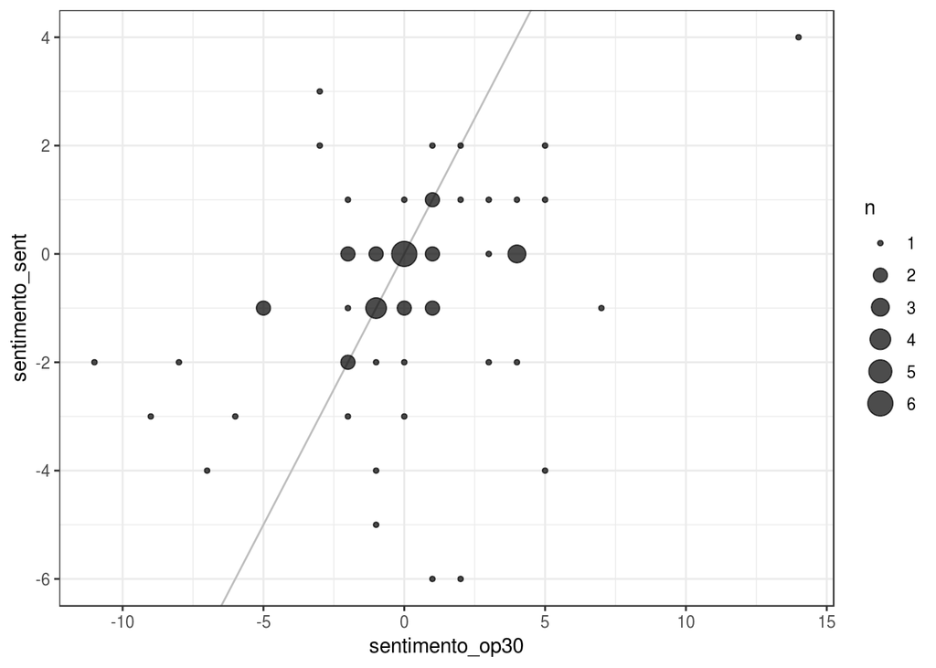

```r
reclamacoes %>%
    ggplot(aes(x = sentimento_op30, y = sentimento_sent)) +
    geom_abline(slope = 1, intercept = 0, color = "grey") +
    geom_count(alpha = .7)
```

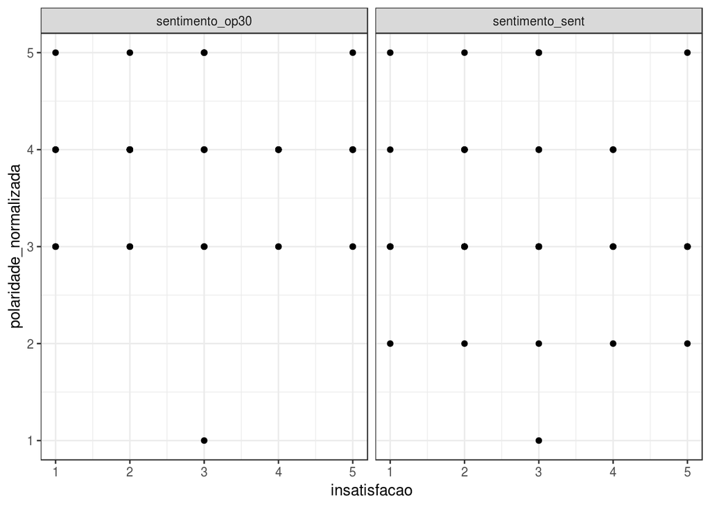

```r
reclamacoes_l %>%
    ggplot(aes(x = insatisfacao, y = polaridade_normalizada, group = insatisfacao)) +
    #geom_abline(slope = 1, intercept = 0, color = "grey") +
    geom_point()  +
    facet_wrap(~ lexico)
```

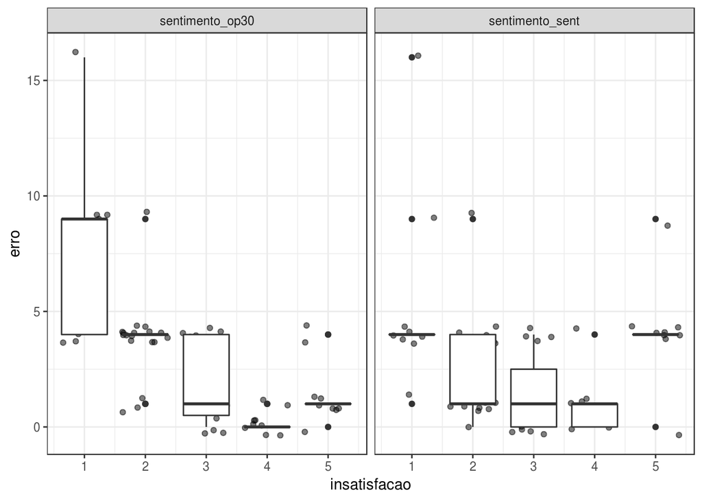

```r
reclamacoes_l %>%
    ggplot(aes(x = insatisfacao, y = erro, group = insatisfacao)) +
    geom_jitter(alpha = .5)  +
    geom_boxplot() +
    facet_wrap(~ lexico)
```